# tier Classification with Ranger model Machine Learning

2024-03-07

This file contains an exploration of the classification analysis for Pick/Ban Rate, Win Rate, and KDA, as attempts to predict tier.

```r
leaguedf <- read_csv('../../data_sets/S13LeagueOfLegendsData.csv', col_types=cols()) %>%
  rename(winr = "Win %", pick = 'Pick %', ban = 'Ban %', roler = 'Role %') %>%
  mutate(pbr = pick + ban, tier = Tier) %>%
  select(-c(1,2,5, 6,7,10,11))


head(leaguedf, 5)
```

```
## # A tibble: 5 × 8
##   Class    Role   winr roler   KDA Patch    pbr tier
##   <chr>    <chr> <dbl> <dbl> <dbl> <chr>  <dbl> <chr>
## 1 Fighter  TOP   0.477 0.916  1.77 13_1  0.186  S
## 2 Mage     MID   0.495 0.946  2.58 13_1  0.0754 S
## 3 Assassin MID   0.484 0.757  2.37 13_1  0.211  S
## 4 Assassin TOP   0.459 0.235  2    13_1  0.156  C
## 5 Marksman MID   0.516 0.660  2.26 13_1  0.0654 A
```

#### Key for Reference

- tier: tier of champion
- winr: winrate of champion
- KDA: Kill/Death/Assist Ratio, $\frac{\text{kills} + \text{assists}}{\text{deaths}}$
- pbr: Pick Ban Rate, Pick rate + Ban rate
- Class: Class of fighter, categorical choice
- ROLE: role that data was collected for
- roler: Percentage of games that were played for this champion on this role
- patch: Patch that data was collected from

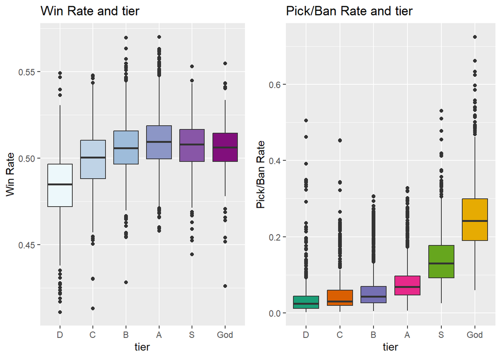

```r
leaguedf$tier <- factor(leaguedf$tier, levels=c('D', 'C', 'B', 'A', 'S', 'God'), ordered=TRUE)
plot1 <- ggplot(data=leaguedf) +
  geom_boxplot(mapping = aes(x = tier, y=winr, fill=tier)) +
  ggtitle('Win Rate and tier') +
  ylab('Win Rate') +
  theme(legend.position='none') +
  scale_fill_brewer(palette="BuPu")

plot2 <- ggplot(data = leaguedf) +
  geom_boxplot(mapping = aes(x= tier, y=pbr, fill=tier)) +
  ggtitle('Pick/Ban Rate and tier') +
  ylab('Pick/Ban Rate') +
  theme(legend.position='none') +
  scale_fill_brewer(palette="Dark2")


grid.arrange(plot1, plot2, ncol=2)
```

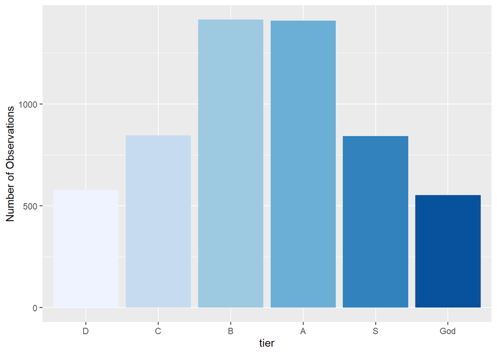

```r
ggplot(data=leaguedf) +
  geom_bar(mapping=aes(x=tier, fill=tier)) +
  scale_fill_brewer('viridis') +
  theme(legend.position = 'none') + ylab("Number of Observations")
```

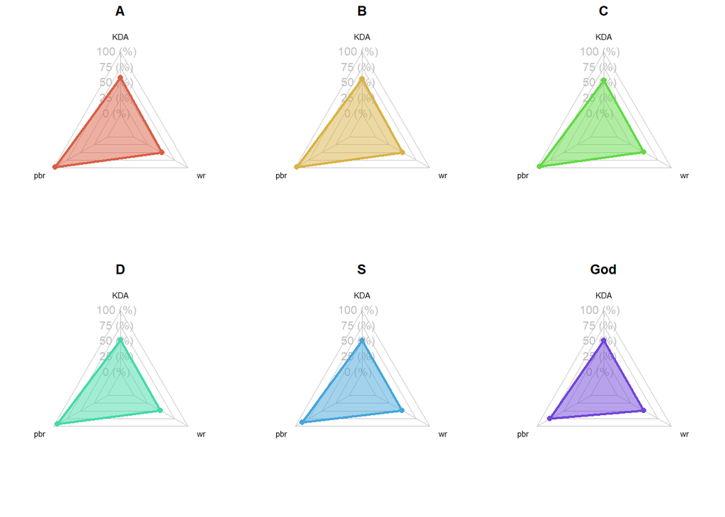

```r
tier_stats <- leaguedf %>%
  group_by(tier) %>%
  summarize(KDA = median(KDA), pbr = median(pbr), wr=median(winr))
tier_stats$tier <-  factor(tier_stats$tier, levels=c('D', 'C', 'B', 'A', 'S', 'God'), ordered=TRUE)
tier_stats <- as_tibble(tier_stats) %>% column_to_rownames(var = "tier")
  # statistics wanted by tier, and change row name to tier

max_min <- data.frame(KDA = c(0, 5), pbr=c(0,1), wr=c(0,1)) #Formatting data for radar chart
rownames(max_min) <- c("Max", "Min")

radar_frame <- rbind(max_min, tier_stats) #final frame for radar chart

#The next two lines split the area for the radar charts
op <- par(mar = c(1.5,1.5,1.5,1.5))
#Split into 6 pieces
par(mfrow = c(2,3))

#Color for each tier
colors = c("#D95F45", "#D9B245", "#62D945", "#45D9AA", "#45A6D9", "#7145D9")

#Title for each chart
titles = c("A", "B", "C", "D", "S", "God")

#make them
for (i in 1:6) {
  create_beautiful_radarchart(data = radar_frame[c(1,2, i+2), ],
                              color = colors[i], title = titles[i]
                              )
} #TODO: FIgure out why its wrong
```

```r
par(op)
```

p.s. I think spider plot is cooler name than radar chart.

## Thoughts

- For higher tiers, such as God, S, and A, it seems that pick ban rate significantly rises.
- For lower tiers, such as D and C, the win rate significantly drops.
- Alone, each of them would likely only do so well to analyze the tiers, but together they seem to be better.
- The number of observations is fairly symmetric with respect to the middle (A/B)

## Moving Forwards

```r
set.seed(27)

# Split the data into test/train. We want 75% for training, and 25% for testing.

inTrain <- createDataPartition(y=leaguedf$tier, p=0.75, list=FALSE)

leagueTraininit <- leaguedf[ inTrain, ]
leagueTestinit <- leaguedf[ -inTrain, ]

#Verify we did it correct, 0.75*5637 is approx 4225
nrow(leagueTraininit)
```

```
## [1] 4229
```

```r
rf_fit <- train(as.factor(tier) ~ .,
                data = leagueTraininit,
                method="ranger")

rf_fit
```

[output not shown]

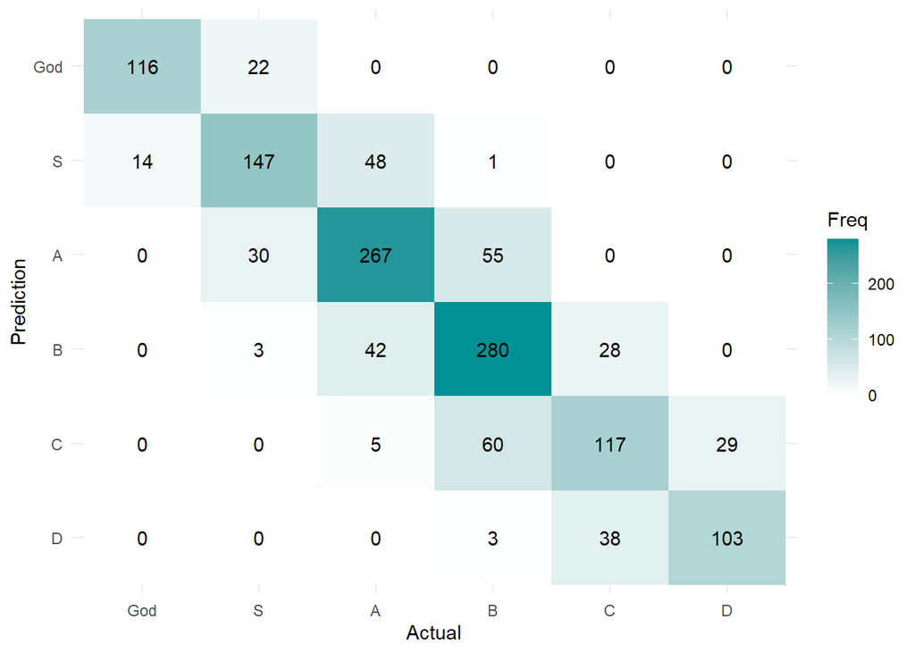

```r
rf_pred <- predict(rf_fit, leagueTestinit)

cm <- confusionMatrix(rf_pred, as.factor(leagueTestinit$tier), dnn = c("Prediction", "Actual"))
plt <- as.data.frame(cm$table)
plt$Prediction <- factor(plt$Prediction, levels=rev(levels(plt$Prediction)))

ggplot(plt, aes(Prediction,Actual, fill=Freq)) +
        geom_tile() + geom_text(aes(label=Freq)) +
        scale_fill_gradient(low="white", high="#009194") +
        labs(x = "Actual",y = "Prediction") +
        scale_y_discrete(labels=c('D', 'C', 'B', 'A', 'S', 'God')) +
        scale_x_discrete(labels=c('God', 'S', 'A', 'B', 'C', 'D')) + theme_minimal()
```

```r
Mode <- function(x) {
  ux <- unique(x)
  ux[which.max(tabulate(match(x, ux)))]
}

Boundarydf = expand.grid(winr = seq(0.4, 0.6, length.out=50), pbr = seq(0, 1, length.out=50), KDA = seq(1, 5, length.out=40), Role = "SUPPORT", `roler` = seq(0.1,1, length.out=10), Patch=c("13_12"), Class=c("Mage", "Support"))
Boundarydf$tier <- predict(rf_fit, Boundarydf)
Boundarydf <- Boundarydf %>%
  group_by(winr, pbr) %>%
  summarize(tier = Mode(tier)) %>%
  ungroup()

write.csv(Boundarydf, "BoundaryFrame.csv")
```

[output not shown]

```r
leaguedf %>% filter(Role=="SUPPORT", Patch=="13_12", Class == "Mage" | Class == "Support")
```

```
## # A tibble: 34 × 8
##    Class   Role     winr roler   KDA Patch    pbr tier
##    <chr>   <chr>   <dbl> <dbl> <dbl> <chr>  <dbl> <ord>
##  1 Mage    SUPPORT 0.468 0.140  2.11 13_12 0.0269 D
##  2 Mage    SUPPORT 0.509 0.167  2.33 13_12 0.0402 C
##  3 Support SUPPORT 0.505 0.94   2.9  13_12 0.026  B
##  4 Mage    SUPPORT 0.511 0.758  1.76 13_12 0.063  B
##  5 Support SUPPORT 0.502 0.98   2.78 13_12 0.0312 B
##  6 Mage    SUPPORT 0.511 0.133  2.02 13_12 0.0353 C
##  7 Mage    SUPPORT 0.511 0.473  1.92 13_12 0.0288 B
##  8 Support SUPPORT 0.498 0.106  2.66 13_12 0.0818 C
##  9 Support SUPPORT 0.520 0.988  3.13 13_12 0.064  S
## 10 Mage    SUPPORT 0.482 0.891  2.56 13_12 0.0633 A
## # ℹ 24 more rows
```

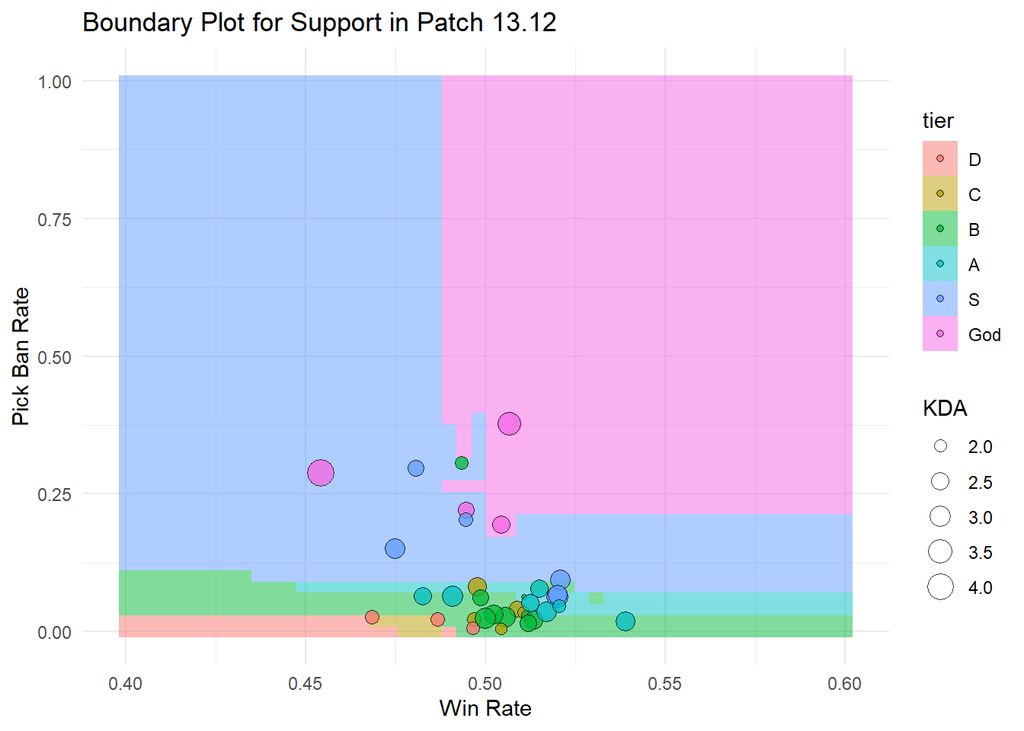

```r
leaguedf %>% filter(Role=="SUPPORT", Patch=="13_12", Class == "Mage" | Class == "Support") %>%
  ggplot(mapping=aes(x=winr, y=pbr, fill=tier)) + geom_raster(data=Boundarydf, alpha=0.5) + geom_point(shape=21, mapping=aes(size=KDA), alpha=0.75) + theme_minimal() + xlab('Win Rate') + ylab('Pick Ban Rate') + ggtitle('Boundary Plot for Support in Patch 13.12')
```

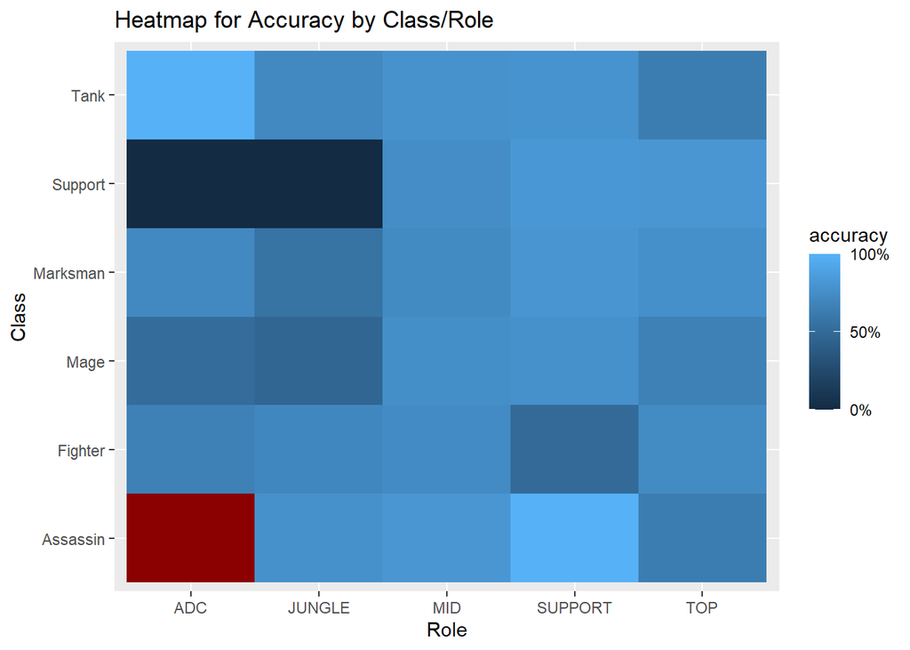

```r
leagueTestinit$pred <- rf_pred
leagueTestinit %>%
  mutate(correct = (pred == tier)) %>% rowwise() %>%
  filter(!(Class == 'NULL')) %>%
  group_by(Role, Class) %>%
  summarize(accuracy = sum(correct)/ n()) %>%
  ungroup() %>% complete(Role, Class, fill=list(NULL)) %>%
  ggplot() + geom_tile(mapping = aes(x = Role, y = Class, fill=accuracy )) +
    ggtitle("Heatmap for Accuracy by Class/Role") +
    scale_fill_continuous(na.value="darkred", breaks=c(0,0.5,1), labels=c("0%", "50%", "100%"), limits=c(0,1))
```

### Preprocessing Data

```r
#First we want to create extra data.




leaguedf_final <- leaguedf %>%
  mutate(Patch = as.numeric(str_replace(Patch, '(.*?)_(.*?)', ''))) #This turns patch to numeric


inTrain <- createDataPartition(y=leaguedf_final$tier, p=0.75, list=FALSE)

leagueTrain <- leaguedf_final[ inTrain, ]
leagueTest <- leaguedf_final[ -inTrain, ]
```

### Hypertuning Model on Preprocess Data

This will take a long time, so please be patient if you run this yourself.

```r
grid <- expand.grid(mtry = c(6,9,12), splitrule=c("extratrees", "gini"), min.node.size=c(1,3,6,10))

fitControl <- trainControl(method='CV', number = 5, verboseIter=FALSE)

fit <- train(as.factor(tier)~.,
             data=leagueTrain,
             method="ranger",
             tuneGrid=grid,
             trControl = fitControl, importance="impurity"
)
```

```r
fit$finalModel
```

```
## Ranger result
##
## Call:
##  ranger::ranger(dependent.variable.name = ".outcome", data = x,      mtry = min(param$mtry, ncol(x)), min.node.size = param$min.node.size,      splitrule = as.character(param$splitrule), write.forest = TRUE,      probability = classProbs, ...)
##
## Type:                             Classification
## Number of trees:                  500
## Sample size:                      4229
## Number of independent variables:  15
## Mtry:                             12
## Target node size:                 1
## Variable importance mode:         impurity
## Splitrule:                        extratrees
## Number of random splits:          1
## OOB prediction error:             25.47 %
```

```r
#This model is not used for classification purposes, but for finding p-values!
ranger_fit <- ranger(formula = tier ~ .,
                       data = leagueTrain,
                       num.trees = 500,
                       mtry = 7,
                       min.node.size = 1,
                       importance = "impurity_corrected",
                       splitrule = "extratrees",
)
```

```r
setwd('../ClassificationML')
saveRDS(fit, "RangerFITwPatch.rds")
```

```r
paste("Initial accuracy is: ", round(sum(leagueTestinit$tier == predict(rf_fit, leagueTestinit)) / length(leagueTestinit$tier), 4)*100, '%', sep='')
```

```
## [1] "Initial accuracy is: 73.15%"
```

```r
paste("Final accuracy is: ", round(sum(leagueTest$tier == predict(fit, leagueTest)) / length(leagueTest$tier), 4)*100, '%', sep='')
```

```
## [1] "Final accuracy is: 94.39%"
```

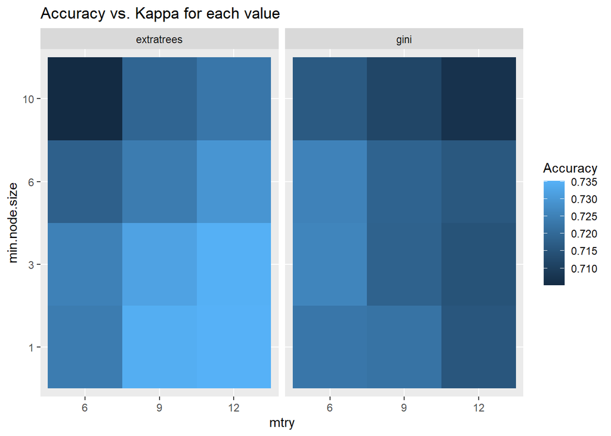

```r
fit$results %>%
  mutate(mtry = as.character(mtry), min.node.size = as.character(min.node.size)) %>%
  mutate(mtry = factor(mtry, levels=c("6", "9", "12", "15"), ordered=TRUE),
         min.node.size = factor(min.node.size, levels = c("1","3", "6", "10"), ordered=TRUE)) %>%
  ggplot() + geom_tile(mapping = aes(x=mtry, y=min.node.size, fill=Accuracy)) + facet_wrap(splitrule ~.) + ggtitle("Accuracy vs. Kappa for each value")
```

### Recreation of Charts

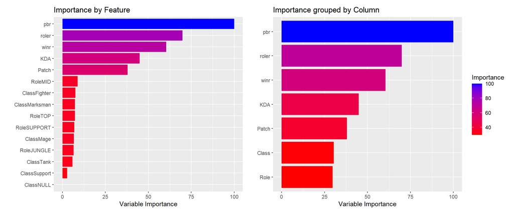

```r
ImpFrame <- varImp(fit)[1] %>%
  as_tibble(rownames="VariableName")
ImpFrame <- ImpFrame$importance %>% as_tibble(rownames="VariableName") %>%
  mutate(VariableName = case_when(
    grepl('Class', VariableName, fixed = TRUE) ~ 'Class',
    grepl("Role", VariableName, fixed = TRUE) ~'Role',
    TRUE ~ VariableName
  ))  %>%
  group_by(VariableName) %>%
  summarize(Overall = sum(Overall)) %>%
  arrange(Overall) %>%
  mutate(VariableName = as.factor(VariableName))


plot1 <- ggplot(varImp(fit)) +
    geom_bar(mapping = aes(x = Feature, y = Importance, fill=Importance), stat = "identity", position = "dodge")  +
    ylab("Variable Importance") +
    xlab("") +
    ggtitle("Importance by Feature") +
    scale_fill_gradient(low = "red", high = "blue") +
  theme(legend.position = "none")

plot2 <- ggplot(ImpFrame) +
  geom_bar(mapping = aes(x = fct_reorder(VariableName, Overall), y = Overall, fill= Overall), stat = "identity", position = "dodge") +
  ylab("Variable Importance") +
  xlab("") +
  ggtitle("Importance grouped by Column") +
  scale_fill_gradient(low = "red", high = "blue") +
  coord_flip() +
  labs(fill = "Importance")
plot1 & plot2
```

```r
finalBoundarydf = expand.grid(winr = seq(0.4, 0.6, length.out=50),
                            pbr = seq(0, 1, length.out=50),
                            KDA = seq(1, 5, length.out=40),
                            Role = "SUPPORT",
                            `roler` = seq(0.1,1, length.out=10),
                            Patch = c(12),
                            Class = c("Mage", "Support"))


finalBoundarydf$tier <- predict(fit, finalBoundarydf) #Why does it say Class not found?
finalBoundarydf <- Boundarydf %>%
  group_by(winr, pbr) %>%
  summarize(tier = Mode(tier)) %>%
  ungroup()

write.csv(Boundarydf, 'FinalBoundarydf.csv')
```

[output not shown]

[figure not shown]

```r
plot1 <- leaguedf %>%
  filter(Role=="SUPPORT", Patch=="13_12", Class == "Mage" | Class == "Support") %>%
  ggplot(mapping=aes(x=winr, y=pbr, fill= tier)) +
    geom_raster(data=Boundarydf, alpha=0.5) +
    geom_point(shape=21, mapping=aes(size=KDA), alpha=0.75) +
    theme_minimal() +
    xlab('Win Rate') +
    ylab('Pick Ban Rate') +
    ggtitle('Pre tuning')

plot2 <- leaguedf %>%
  filter(Role=="SUPPORT", Patch=="13_12", Class == "Mage" | Class == "Support") %>%
  ggplot(mapping=aes(x=winr, y=pbr, fill= tier))+
    geom_raster(data=finalBoundarydf, alpha=0.5) +
    geom_point(shape=21, mapping=aes(size=KDA), alpha=0.75) +
    theme_minimal() +
    xlab('Win Rate') +
    ylab('') +
    ggtitle('Post Tuning')

patch <- plot1 +  plot2 & theme(legend.position="bottom")
patch + plot_layout(ncol=2,guides="collect") + plot_annotation(title="Boundary Plots for Support on Patch 13.12", theme = theme(plot.title = element_text(size = 20)))
```

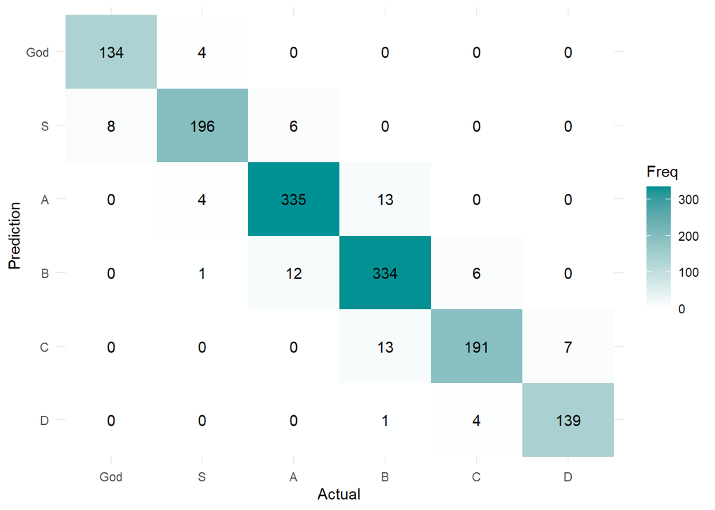

```r
rf_pred <- predict(fit, leagueTest)

cm <- confusionMatrix(rf_pred, as.factor(leagueTest$tier), dnn = c("Prediction", "Actual"))
plt <- as.data.frame(cm$table)
plt$Prediction <- factor(plt$Prediction, levels=rev(levels(plt$Prediction)))

ggplot(plt, aes(Prediction,Actual, fill=Freq)) +
        geom_tile() + geom_text(aes(label=Freq)) +
        scale_fill_gradient(low="white", high="#009194") +
        labs(x = "Actual",y = "Prediction") +
        scale_y_discrete(labels=c('D', 'C', 'B', 'A', 'S', 'God')) +
        scale_x_discrete(labels=c('God', 'S', 'A', 'B', 'C', 'D')) + theme_minimal()
```

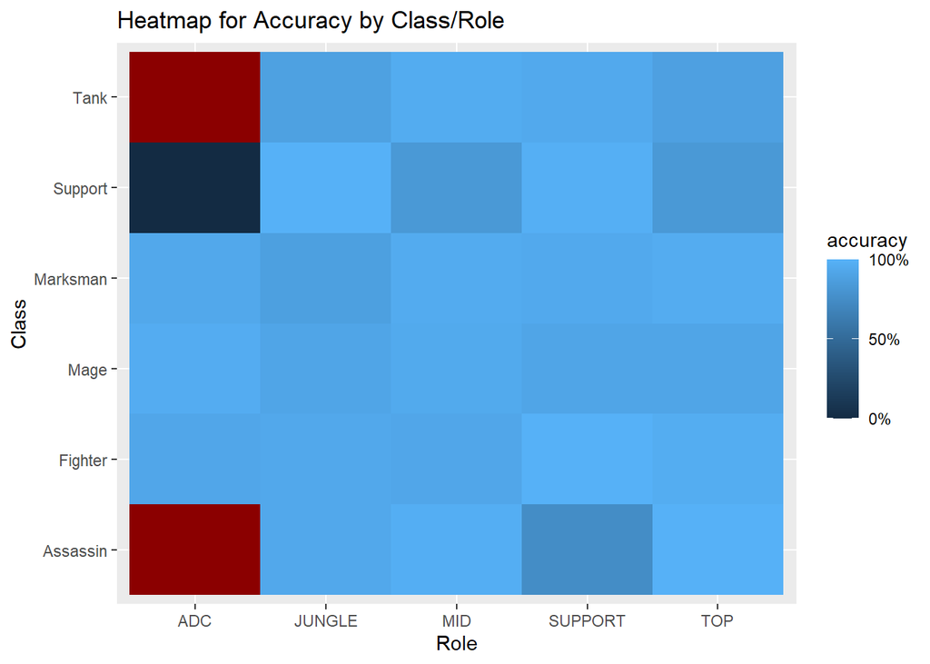

```r
leagueTest$pred <- rf_pred
leagueTest %>%
  mutate(correct = (pred == tier)) %>% rowwise() %>%
  filter(!(Class == 'NULL')) %>%
  group_by(Role, Class) %>%
  summarize(accuracy = sum(correct)/ n()) %>%
  ungroup() %>% complete(Role, Class, fill=list(NULL)) %>%
  ggplot() + geom_tile(mapping = aes(x = Role, y = Class, fill=accuracy )) +
    ggtitle("Heatmap for Accuracy by Class/Role") +
    scale_fill_continuous(na.value="darkred", breaks=c(0,0.5,1), labels=c("0%", "50%", "100%"), limits=c(0,1))
```

```r
importance_pvalues(ranger_fit,
                   method= c("altmann"),
                   formula = tier ~.,
                   data = leaguedf_final)
```

[output not shown]